# Regression modelling of Burnout score

# Table of Contents

## Project description and content of the dataset

This project is an attempt

i) to find regression models that can best predict the metric burnout score with the inclusion of metric and categorical parameters given in the data set, and

ii) to estimate the impact of various factors (work circumstances, personal factors) on possible burnout situations of company employees.

The dataset has been taken from https://www.kaggle.com/blurredmachine/are-your-employees-burning-out.

Only the train dataset has been used, as the related test dataset doesn't contain values for the dependent variable which I would like to have, in order to evaluate performance of my models. The train dataset was downloaded and worked on locally.

The dataset consists of 9 columns as follows:

- Employee ID: The unique ID allocated for each employee (example: fffe390032003000)
- Date of Joining: The date-time when the employee has joined the organization (example: 2008-12-30)
- Gender: The gender of the employee (Male/Female)
- Company Type: The type of company where the employee is working (Service/Product)
- WFH Setup Available: Is the work from home facility available for the employee (Yes/No)
- Designation: The designation of the employee of work in the organization, in the range of [0.0, 5.0]. The bigger the number, the higher is designation.
- Resource Allocation: The amount of resource allocated to the employee to work, ie. number of working hours, in the range of [1.0, 10.0]. A higher number means more workload.
- Mental Fatigue Score: The level of fatigue mentally the employee is facing, in the range of [0.0, 10.0] where 0.0 means no fatigue and 10.0 means completely fatigue.
- Burn Rate: The value to be predicted for each employee, telling the rate of Burn out while working, in the range of [0.0, 1.0] where the higher the value is the higher is the burn out.

```python
import numpy as np
import pandas as pd
import seaborn as sns
from sklearn import preprocessing

np.random.seed(1) # to make numpy's output identical at every run
```

```python
df = pd.read_csv('train.csv')
```

## Initial data management

```python
df.head(3)
```

|  | Employee ID | Date of Joining | Gender | Company Type | WFH Setup Available | Designation | Resource Allocation | Mental Fatigue Score | Burn Rate |
| --- | --- | --- | --- | --- | --- | --- | --- | --- | --- |
| 0 | fffe32003000360033003200 | 2008-09-30 | Female | Service | No | 2.0 | 3.0 | 3.8 | 0.16 |
| 1 | fffe3700360033003500 | 2008-11-30 | Male | Service | Yes | 1.0 | 2.0 | 5.0 | 0.36 |
| 2 | fffe31003300320037003900 | 2008-03-10 | Female | Product | Yes | 2.0 | NaN | 5.8 | 0.49 |

```python
# Shortening variable names
df.columns = ['ID','Date', 'Gender', 'Company_type', 'WFH', 'Designation', 'Ressource', 'Fatigue', 'Burn_Rate']
```

```python
# Describing metric variables
df.describe().T
```

|  | count | mean | std | min | 25% | 50% | 75% | max |
| --- | --- | --- | --- | --- | --- | --- | --- | --- |
| Designation | 22750.0 | 2.178725 | 1.135145 | 0.0 | 1.00 | 2.00 | 3.00 | 5.0 |
| Ressource | 21369.0 | 4.481398 | 2.047211 | 1.0 | 3.00 | 4.00 | 6.00 | 10.0 |
| Fatigue | 20633.0 | 5.728188 | 1.920839 | 0.0 | 4.60 | 5.90 | 7.10 | 10.0 |
| Burn_Rate | 21626.0 | 0.452005 | 0.198226 | 0.0 | 0.31 | 0.45 | 0.59 | 1.0 |

```python
# Describing categorical variables
for c in ['Gender', 'Company_type', 'WFH']:
    print(f"{c}\n{df[c].value_counts()}\n****************************")
```

```
Gender
Female    11908
Male      10842
Name: Gender, dtype: int64
Company_type
Service    14833
Product     7917
Name: Company_type, dtype: int64
WFH
Yes    12290
No     10460
Name: WFH, dtype: int64
```

#### Defining strategy of dealing with missing values

```python
# Detecting missing values:
df.info()
```

```
<class 'pandas.core.frame.DataFrame'>
RangeIndex: 22750 entries, 0 to 22749
Data columns (total 9 columns):
ID              22750 non-null object
Date            22750 non-null object
Gender          22750 non-null object
Company_type    22750 non-null object
WFH             22750 non-null object
Designation     22750 non-null float64
Ressource       21369 non-null float64
Fatigue         20633 non-null float64
Burn_Rate       21626 non-null float64
dtypes: float64(4), object(5)
memory usage: 1.6+ MB
```

```python
# Amount of missing values:
for i in ["Ressource", "Fatigue", "Burn_Rate"]:
    print(f'NaNs in "{i}":', df[i].isnull().sum(),', or', round(df[i].isnull().sum()/len(df[i])*100, 1),'% of all records.')
```

```
NaNs in "Ressource": 1381 , or 6.1 % of all records.
NaNs in "Fatigue": 2117 , or 9.3 % of all records.
NaNs in "Burn_Rate": 1124 , or 4.9 % of all records.
```

```python
# Alternatively, in this format:
df_null_summary = pd.concat([df.isnull().sum(), df.isnull().sum() * 100 / df.isnull().count()], axis = 1)
df_null_summary.columns = ['Null Record Count', 'Percentage of Null Records']
df_null_summary.sort_values(by='Percentage of Null Records', ascending=False).style.background_gradient(cmap ='YlOrRd')
```

|  | Null Record Count | Percentage of Null Records |
| --- | --- | --- |
| Fatigue | 2117 | 9.30549 |
| Ressource | 1381 | 6.07033 |
| Burn_Rate | 1124 | 4.94066 |
| ID | 0 | 0 |
| Date | 0 | 0 |
| Gender | 0 | 0 |
| Company_type | 0 | 0 |
| WFH | 0 | 0 |
| Designation | 0 | 0 |

```python
# There shouldn't be any missing values in the dependent variable.
n = len(df['Burn_Rate']) - df['Burn_Rate'].isna().sum()
print(f"If we delete records with NaNs in 'Burn Rate', {n} observations remain.")
```

```
If we delete records with NaNs in 'Burn Rate', 21626 observations remain.
```

```python
# Deleting records with NaNs in the dependent variable 'Burn Rate':
df = df[df['Burn_Rate'].notna()]
```

What if we just delete missing values in 'Ressource' and 'Fatigue'? Will there be still enough records left for modelling? Will the data structure / main distributions remain similar?

```python
# The shape of initial dataset:
df.shape
```

```
(21626, 9)
```

```python
# Creating a copy of the dataframe but without missing values in 'Ressource' and 'Fatigue'.
# Its shape:
df_nomiss = df[df['Ressource'].notna() & df['Fatigue'].notna()]
df_nomiss.shape
```

```
(18590, 9)
```

```python
# The target variable is metric and will be now split into 10 categories, for the purpose of distributions' comparison:
df["Burn_Rate_cut"] = pd.cut(df['Burn_Rate'], 10)
df_nomiss["Burn_Rate_cut"] = pd.cut(df_nomiss['Burn_Rate'], 10)
```

```python
# Comparing the main distributions ("Gender", "Company_type", "WFH" and "Burn_Rate") of dataframes
# with and without missing values:
```

```python
def distrib_check(param):
    tab1 = df.groupby(by=[param]).agg({param: 'count'})
    tab1['%, ohne NaNs'] = round((tab1[param] / tab1[param].sum() * 100), 1)
    tab2 = df_nomiss.groupby(by=[param]).agg({param: 'count'})
    tab2['%, ohne NaNs'] = round((tab2[param] / tab2[param].sum() * 100), 1)
    result = pd.concat([tab1, tab2], axis=1)
    result.columns = [f'{param} before', '% before', f'{param} after', '% after']
    return result
```

```python
for i in ['Gender','Company_type','WFH', 'Burn_Rate_cut']:
    print(f'{distrib_check(i)}\n')
```

```
        Gender before  % before  Gender after  % after
Gender
Female          11349      52.5          9747     52.4
Male            10277      47.5          8843     47.6

              Company_type before  % before  Company_type after  % after
Company_type
Product                      7502      34.7                6416     34.5
Service                     14124      65.3               12174     65.5

     WFH before  % before  WFH after  % after
WFH
No         9941      46.0       8560     46.0
Yes       11685      54.0      10030     54.0

               Burn_Rate_cut before  % before  Burn_Rate_cut after  % after
Burn_Rate_cut
(-0.001, 0.1]                   922       4.3                  784      4.2
(0.1, 0.2]                     1475       6.8                 1263      6.8
(0.2, 0.3]                     2692      12.4                 2309     12.4
(0.3, 0.4]                     3732      17.3                 3203     17.2
(0.4, 0.5]                     4205      19.4                 3636     19.6
(0.5, 0.6]                     3791      17.5                 3262     17.5
(0.6, 0.7]                     2611      12.1                 2247     12.1
(0.7, 0.8]                     1360       6.3                 1163      6.3
(0.8, 0.9]                      579       2.7                  503      2.7
(0.9, 1.0]                      259       1.2                  220      1.2
```

If all cases with missing values in "Resource" and "Fatigue" are removed, then  
1) (21626 - 18590 = ) 3036 records are omitted, or 14% of all records,  
2) the most important distributions ("Gender", "Company_type", "WFH" and "Burn_Rate") remain almost unchanged.

This means that the remaining size of the dataset is sufficient for modelling and the removal of all NaNs would affect the data structure very little, therefore I could remove the missing values from "Resource" and "Fatigue" altogether.

However, for the sake of training, I would like to impute them.

'Ressource' and 'Fatigue' are metric variables, so I'd probably replace missing values with arithmetic means, however, first I'd like to see if means are notably different for various groups, as defined by categorical variables.

```python
def means_check(param, group_var):
    tab = df.groupby(by=group_var).agg({param: 'mean'})
    return tab
```

```python
for i in ['Ressource', 'Fatigue']:
    for j in ['Gender', 'Company_type', 'WFH']:
        print(means_check(i, j))
```

```
        Ressource
Gender
Female   4.209054
Male     4.788029
              Ressource
Company_type
Product        4.464590
Service        4.493992
     Ressource
WFH
No    5.119170
Yes   3.943909
         Fatigue
Gender
Female  5.462421
Male    6.024018
               Fatigue
Company_type
Product       5.722103
Service       5.733950
      Fatigue
WFH
No   6.304943
Yes  5.238881
```

The means are indeed quite different in groups 'Gender' and 'WFH'. So, mean values will be calculated separately for each group built by intersection of these two variables - this will be done after splitting the dataset into train and test parts.

#### Some more data preparation

```python
# Re-formatting the column "Date":
df['Date'] = pd.to_datetime(df['Date'])
```

```python
# Calculating the length of employment for each employee (in days):
df['Tenure'] = (df['Date'].max() - df['Date']).dt.days
```

### Optimizing memory usage

```python
# Re-sorting and deleting some columns:
df = df[[#'ID', 'Date',
         'Gender', 'Company_type', 'Tenure', 'WFH', 'Designation', 'Ressource', 'Fatigue', 'Burn_Rate_cut', 'Burn_Rate']]
```

```python
df.dtypes
```

```
Gender             object
Company_type       object
Tenure              int64
WFH                object
Designation       float64
Ressource         float64
Fatigue           float64
Burn_Rate_cut    category
Burn_Rate         float64
dtype: object
```

```python
mem1 = df.memory_usage(deep=True).sum()
```

```python
# Re-formatting "object" columns to "category"
df.loc[:, ['Gender', 'Company_type', 'WFH']] = df.loc[:, ['Gender', 'Company_type', 'WFH']].astype('category')
```

```python
# Downcasting floats (except for 'Burn_Rate')
df.loc[:,['Designation', 'Ressource', 'Fatigue']] = df.loc[:,['Designation', 'Ressource', 'Fatigue']].apply(pd.to_numeric, downcast="float")
```

```python
# Downcasting integers
df.loc[:,['Tenure']] = df.loc[:,['Tenure']].apply(pd.to_numeric, downcast="integer")
```

```python
mem2 = df.memory_usage(deep=True).sum()
```

```python
reduction = (mem1 - mem2) / mem1 * 100
print(f"The memory usage has been reduced by {reduction:0.1f}%.")
```

```
The memory usage has been reduced by 85.5%.
```

### Splitting the data into train and test set

```python
# StratifiedShuffleSplit will be used for splitting and for it to work properly, the df must have no missing indices.
# Currently, there are some, as I have deleted some cases with missings in the dependent variable.
# Therefore I am re-indexing the df:

df.reset_index(inplace=True)
```

```python
# StratifiedShuffleSplit splits the data taking account of a stratifying variable
# and preserving the percentage of samples for each class.
# Burn_Rate_cut is selected as the stratifying variable.

from sklearn.model_selection import StratifiedShuffleSplit

split = StratifiedShuffleSplit(n_splits=1, test_size=0.2, random_state=1)
for train_index, test_index in split.split(df, df["Burn_Rate_cut"]):
    train_set = df.loc[train_index]
    test_set = df.loc[test_index]
```

```python
# The columns 'index' and 'Burn_Rate_cut' are not needed anymore and can be deleted:
train_set.drop(columns=['index', 'Burn_Rate_cut'], inplace=True)
test_set.drop(columns=['index', 'Burn_Rate_cut'], inplace=True)
```

### Train data visualization

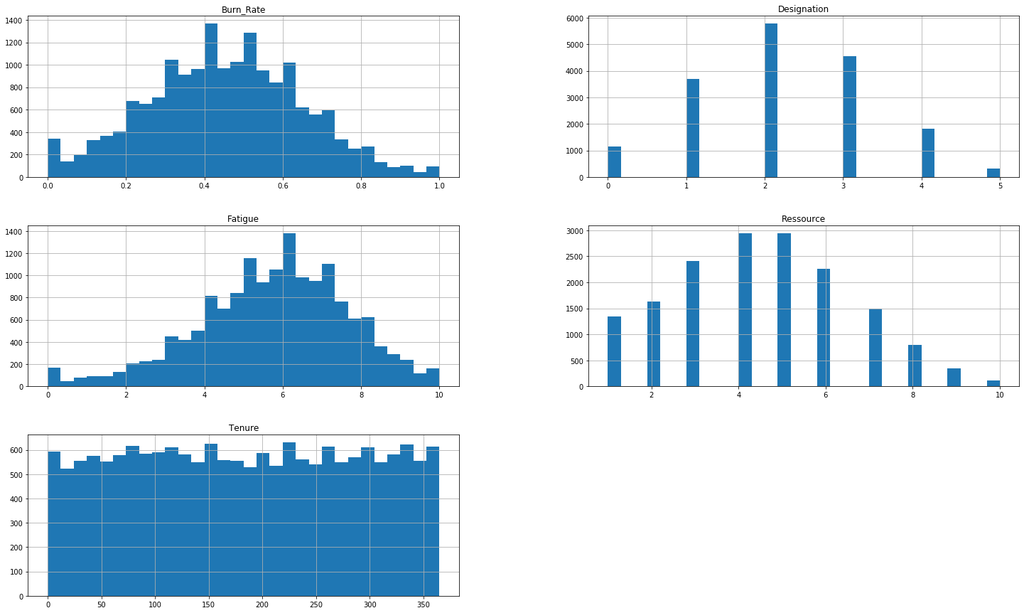

```python
import matplotlib.pyplot as plt
train_set.hist(bins=30, figsize=(25,15))
plt.show()
```

The distributions of Burn Rate, Designation, Fatigue, and Ressource look almost normal. Various values of Tenure are almost evenly spread across the sample.

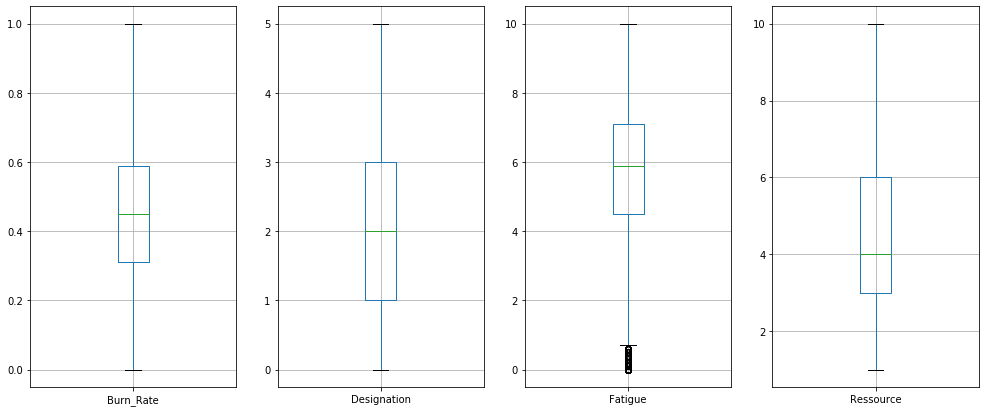

```python
# Any outliers?

fig, axes = plt.subplots(1,4)
df = train_set[["Burn_Rate", "Designation", "Fatigue", "Ressource"]]

for i, el in enumerate(list(df.columns.values)):
    a = df.boxplot(el, ax=axes.flatten()[i])

fig.set_size_inches(17, 7)
plt.show()
```

No outliers visible; those beyond the lower whisker for 'Fatigue' aren't outliers in their essence but normal observations in a skewed distribution.

```python
corr_matrix = train_set.corr()
corr_matrix['Burn_Rate'].sort_values(ascending=False)
```

```
Burn_Rate      1.000000
Fatigue        0.944494
Ressource      0.856130
Designation    0.737368
Tenure         0.003592
Name: Burn_Rate, dtype: float64
```

Burn_Rate correlates strongly and positively with Fatigue, Ressource, and Designation.

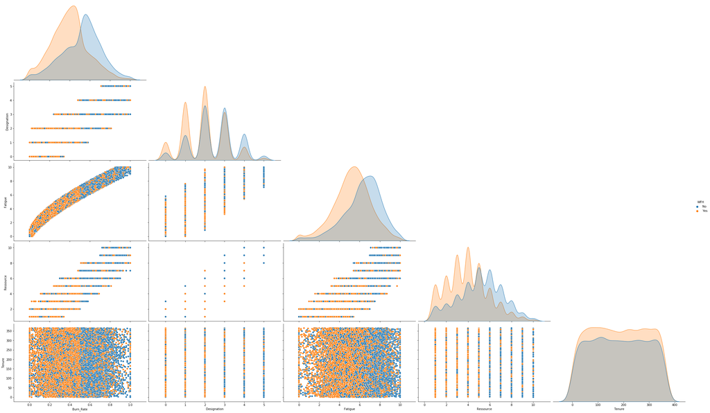

```python
sns.pairplot(
    train_set[["Burn_Rate", "Designation", "Fatigue", "Ressource", 'Tenure', 'WFH']],
    hue='WFH',
    height=4,
    aspect=10/6,
    corner=True)
```

It can be assumed that Fatigue, Ressource, and Designation will be the factors with most influence on Burn Rate.

The dependence of Burn Rate from each of these factors seems to be linear.

'Work From Home' (WFH) is coded here as: 'No' = blue, 'Yes' = orange. Higher Burn Rate and Fatigue have a stronger association with WFH = 'No' than with WFH = 'Yes'. WFH is therefore possibly a factor influencing Burn Rate: the home office option seems to provide some relief to employees.

Length of employment ('Tenure') has no discernible influence on the Burn Rate.

### Data preparation for machine learning

#### Imputing missing values

As discussed above, missing values in 'Ressource' and 'Fatigue' will be replaced by means calculated separately for each group built by intersection of 'Gender' and 'WFH'.

```python
for i in [train_set, test_set]:
    for j in ['Ressource', 'Fatigue']:
        i[j] = i[j].fillna(i.groupby(['Gender', 'WFH'])[j].transform('mean'))
```

#### Scaling metric variables using MinMaxScaler

```python
# MinMaxScaler scales and translates each feature individually
# such that it is in the given range on the training set, e.g. between zero and one.

from sklearn.preprocessing import MinMaxScaler
scaler = MinMaxScaler()
```

```python
metric = ['Tenure', 'Designation', 'Ressource', 'Fatigue']

for i in metric:
    train_set[[i]] = scaler.fit_transform(train_set[[i]])
    test_set[[i]] = scaler.transform(test_set[[i]])
```

#### Converting categorial variables with OrdinalEncoder

'Gender', 'Company_type', and 'WFH' - there are only two values in each of these variables, so OrdinalEncoder is enough: it will convert the labels into 0 and 1.

```python
from sklearn.preprocessing import OrdinalEncoder

ordinal_encoder = OrdinalEncoder()
```

```python
for i in [train_set, test_set]:
    for j in [['Gender', 'Company_type', 'WFH']]:
        i[j] = ordinal_encoder.fit_transform(i[j])
```

#### Separating X from y

```python
y_train = train_set.iloc[:, 7]
X_train = train_set.iloc[:, 0:-1]
y_test = test_set.iloc[:, 7]
X_test = test_set.iloc[:, 0:-1]
```

```python
# Converting the datasets into numpy arrays
y_train = y_train.to_numpy()
X_train = X_train.to_numpy()
y_test = y_test.to_numpy()
X_test = X_test.to_numpy()
```

## Machine learning part

As the response variable is metric, I select four regressors which should be able to deliver metric predictions: Linear Regression, Decision Tree Regressor, Random Forest Regressor, and Support Vector Regressor.

```python
from sklearn.linear_model import LinearRegression
from sklearn.tree import DecisionTreeRegressor
from sklearn.ensemble import RandomForestRegressor
from sklearn.svm import SVR
from sklearn.metrics import mean_squared_error
random_state=1
```

The following ratios will be used for the evaluation and comparison of the models:

- Root-mean-square error - indicates how much a point estimator scatters around the value to be estimated.
- R2 - is used to assess the goodness of fit of a regression and describes the share of the sum of squares explained by the regression in the total sum of squares to be explained. For my models, I will try to target R2=0.9 as the minimum acceptable value.

### Initial fitting

Four selected regressors will be first applied with their basic parameters.

```python
lin_reg = LinearRegression()
tree_reg = DecisionTreeRegressor(random_state=random_state)
forest_reg = RandomForestRegressor(n_estimators=100, oob_score=True, random_state=random_state)
svm_reg = SVR(kernel="linear", gamma='scale')
```

```python
for m in [lin_reg, tree_reg, forest_reg, svm_reg]:
    m.fit(X_train, y_train)
    burnout_predictions = m.predict(X_train)
    mse = mean_squared_error(y_train, burnout_predictions)
    rmse = np.sqrt(mse)
    r2 = m.score(X_train, y_train)

    print(f"{m}:\nRMSE = {rmse}\nr2 = {r2}\n")
```

```
LinearRegression(copy_X=True, fit_intercept=True, n_jobs=None, normalize=False):
RMSE = 0.07002757774550321
r2 = 0.8753048937308748

DecisionTreeRegressor(criterion='mse', max_depth=None, max_features=None,
                      max_leaf_nodes=None, min_impurity_decrease=0.0,
                      min_impurity_split=None, min_samples_leaf=1,
                      min_samples_split=2, min_weight_fraction_leaf=0.0,
                      presort=False, random_state=1, splitter='best'):
RMSE = 0.0048977010847153155
r2 = 0.9993900478694202

RandomForestRegressor(bootstrap=True, criterion='mse', max_depth=None,
                      max_features='auto', max_leaf_nodes=None,
                      min_impurity_decrease=0.0, min_impurity_split=None,
                      min_samples_leaf=1, min_samples_split=2,
                      min_weight_fraction_leaf=0.0, n_estimators=100,
                      n_jobs=None, oob_score=True, random_state=1, verbose=0,
                      warm_start=False):
RMSE = 0.024462398199454283
r2 = 0.9847836929379499

SVR(C=1.0, cache_size=200, coef0=0.0, degree=3, epsilon=0.1, gamma='scale',
    kernel='linear', max_iter=-1, shrinking=True, tol=0.001, verbose=False):
RMSE = 0.07047330926281938
r2 = 0.8737124517771603
```

Decision Tree Regressor and Random Forest Regressor have a suspiciously high R2 score measured on train dataset; Root-mean-square error (RMSE) of the Decision Tree Regressor is extremely small - overfitting? Cross-validation will show.

### Cross-validation

```python
from sklearn.model_selection import cross_val_score
from sklearn.metrics import mean_squared_error
```

```python
def crossval(model, n_folds):
    scores = cross_val_score(model, X_train, y_train,
                                 scoring="neg_mean_squared_error", cv=n_folds)
    rmse_scores = np.sqrt(-scores)
    print(f"Cross-validation for {model}\nroot-mean-square error | R2: \n", end="")
    print(np.mean(rmse_scores), end=" | ")

    scores = cross_val_score(model, X_train, y_train,
                                 scoring="r2", cv=n_folds)
    print(np.mean(scores))
```

```python
crossval(lin_reg, 10)
```

```
Cross-validation for LinearRegression(copy_X=True, fit_intercept=True, n_jobs=None, normalize=False)
root-mean-square error | R2:
0.0700479444490704 | 0.8750631217421889
```

```python
crossval(tree_reg, 10)
```

```
Cross-validation for DecisionTreeRegressor(criterion='mse', max_depth=None, max_features=None,
                      max_leaf_nodes=None, min_impurity_decrease=0.0,
                      min_impurity_split=None, min_samples_leaf=1,
                      min_samples_split=2, min_weight_fraction_leaf=0.0,
                      presort=False, random_state=1, splitter='best')
root-mean-square error | R2:
0.08454215217526995 | 0.8177950404808276
```

```python
crossval(forest_reg, 5) # Only five folds, otherwise it takes too long
```

```
Cross-validation for RandomForestRegressor(bootstrap=True, criterion='mse', max_depth=None,
                      max_features='auto', max_leaf_nodes=None,
                      min_impurity_decrease=0.0, min_impurity_split=None,
                      min_samples_leaf=1, min_samples_split=2,
                      min_weight_fraction_leaf=0.0, n_estimators=100,
                      n_jobs=None, oob_score=True, random_state=1, verbose=0,
                      warm_start=False)
root-mean-square error | R2:
0.064573148858306 | 0.8938267972450802
```

```python
crossval(svm_reg, 5) # Only five folds, otherwise it takes too long
```

```
Cross-validation for SVR(C=1.0, cache_size=200, coef0=0.0, degree=3, epsilon=0.1, gamma='scale',
    kernel='linear', max_iter=-1, shrinking=True, tol=0.001, verbose=False)
root-mean-square error | R2:
0.07052097438430857 | 0.8734163106578873
```

I will use Grid Search, to find somewhat better combinations of parameters for most models.

### Grid Search

Some fine-tuning of parameters.

```python
from sklearn.model_selection import GridSearchCV
```

```python
def gridsearch(model, n_folds):
    grid_search = GridSearchCV(model, param_grid, cv=n_folds,
                               scoring='neg_mean_squared_error',
                               return_train_score=True)
    grid_search.fit(X_train, y_train)

    print("The best parameters: \n", grid_search.best_params_, "\n")
    print("The best estimator: \n", grid_search.best_estimator_)
```

#### Decision Tree Regressor

```python
# try combinations of the following hyperparameters:
param_grid = [
    {'max_depth': [5, 6, 7], 'max_features':[4, 5, 6], 'min_samples_leaf': [15, 20, 25]},
    ]

gridsearch(tree_reg, 10)
```

```
The best parameters:
 {'max_depth': 7, 'max_features': 6, 'min_samples_leaf': 15}

The best estimator:
 DecisionTreeRegressor(criterion='mse', max_depth=7, max_features=6,
                      max_leaf_nodes=None, min_impurity_decrease=0.0,
                      min_impurity_split=None, min_samples_leaf=15,
                      min_samples_split=2, min_weight_fraction_leaf=0.0,
                      presort=False, random_state=1, splitter='best')
```

Decision Tree Regressor: The best parameters suggested by GridSearch are:  
{max_depth=7, max_features=6, min_samples_leaf=15}.

However, I would deviate from these suggested parameters, in order to make the tree shorter and more coarse and less prone to overfitting.

I would choose these parameters:  
{max_depth=6, max_features=6, min_samples_leaf=25}

#### Random Forest Regressor

```python
# try combinations of the following hyperparameters:
param_grid = [
    {'max_features': [3, 4, 5]},
    ]

gridsearch(forest_reg, 3)
```

```
The best parameters:
 {'max_features': 4}

The best estimator:
 RandomForestRegressor(bootstrap=True, criterion='mse', max_depth=None,
                      max_features=4, max_leaf_nodes=None,
                      min_impurity_decrease=0.0, min_impurity_split=None,
                      min_samples_leaf=1, min_samples_split=2,
                      min_weight_fraction_leaf=0.0, n_estimators=100,
                      n_jobs=None, oob_score=True, random_state=1, verbose=0,
                      warm_start=False)
```

Training the Random Forest Regressor with combinations of the following parameters:  
'n_estimators': [3, 10], 'max_features': [4, 6], 'criterion': ['mse', 'mae']

led to this suggestion:  
'criterion': 'mae', 'max_features': 4, 'n_estimators': 10

So, 4 features should be fine, hovewer, using criterion='mae' slows down the training immensely, so for the sake of performance I will choose 'mse'.

I have only proved if 'max_features' should be (3, 4, or 5) and it is {'max_features': 4}.

Number of trees has been initially set to 100 and Grid Search would probably suggest more than that if it might choose but in order to keep execution time acceptable I will leave n_estimators=100.

#### Support Vector Regressor

```python
# try combinations of the following hyperparameters:
param_grid = [
    {'kernel':['rbf'], 'C':[1/10, 1, 10], 'epsilon': [0.025, 0.05]}
    ]

gridsearch(svm_reg, 3)
```

```
The best parameters:
 {'C': 10, 'epsilon': 0.05, 'kernel': 'rbf'}

The best estimator:
 SVR(C=10, cache_size=200, coef0=0.0, degree=3, epsilon=0.05, gamma='scale',
    kernel='rbf', max_iter=-1, shrinking=True, tol=0.001, verbose=False)
```

Training the Support Vector Regressor with combinations of the following parameters: 'kernel':['linear', 'rbf'], 'C':[1/100, 1/10, 1], 'epsilon': [0.05, 0.1]

led to this suggestion: 'C': 1, 'epsilon': 0.05, 'kernel': 'rbf'

After another evaluation, I am keeping 'kernel': 'rbf' and taking newly evaluated parameters 'C': 10 and 'epsilon': 0.05 as final / the most optimal for the Support Vector Regressor model.

#### Re-fitting models with the best found parameters

```python
lin_reg2 = LinearRegression()
tree_reg2 = DecisionTreeRegressor(max_depth=6, max_features=6, min_samples_leaf=25, random_state=random_state)
forest_reg2 = RandomForestRegressor(n_estimators=100, criterion='mse', max_features=4, oob_score=True, random_state=random_state)
svm_reg2 = SVR(kernel="rbf", gamma='scale', C=10, epsilon=0.05)
```

```python
for m in [lin_reg2, tree_reg2, forest_reg2, svm_reg2]:
    m.fit(X_train, y_train)
    burnout_predictions = m.predict(X_train)
    mse = mean_squared_error(y_train, burnout_predictions)
    rmse = np.sqrt(mse)
    r2 = m.score(X_train, y_train)

    print(f"{m}:\nRMSE = {rmse}\nr2 = {r2}\n")
```

```
LinearRegression(copy_X=True, fit_intercept=True, n_jobs=None, normalize=False):
RMSE = 0.07002757774550321
r2 = 0.8753048937308748

DecisionTreeRegressor(criterion='mse', max_depth=6, max_features=6,
                      max_leaf_nodes=None, min_impurity_decrease=0.0,
                      min_impurity_split=None, min_samples_leaf=25,
                      min_samples_split=2, min_weight_fraction_leaf=0.0,
                      presort=False, random_state=1, splitter='best'):
RMSE = 0.06708325730386372
r2 = 0.885570108756314

RandomForestRegressor(bootstrap=True, criterion='mse', max_depth=None,
                      max_features=4, max_leaf_nodes=None,
                      min_impurity_decrease=0.0, min_impurity_split=None,
                      min_samples_leaf=1, min_samples_split=2,
                      min_weight_fraction_leaf=0.0, n_estimators=100,
                      n_jobs=None, oob_score=True, random_state=1, verbose=0,
                      warm_start=False):
RMSE = 0.024221775779071534
r2 = 0.9850815686528749

SVR(C=10, cache_size=200, coef0=0.0, degree=3, epsilon=0.05, gamma='scale',
    kernel='rbf', max_iter=-1, shrinking=True, tol=0.001, verbose=False):
RMSE = 0.06300259513602098
r2 = 0.8990681860218369
```

Decision Tree Regressor: much more realistic RMSE and R2 than with default parameters.  
Random Forest Regressor: again, too good RMSE and R2 but cross-validation showed that they get much closer to those from other models when applied to unseen data.  
Support Vector Regressor: slightly better RMSE and R2 than with default parameters.

Support Vector Regressor has now a higher R2 than Linear Regressor.

```python
# Feature importance by Linear Regression:

for m in [lin_reg2]:
    print(f"{m}\n Features' coefficients:\n 'Gender', 'Company_type', 'Tenure', 'WFH', 'Designation', 'Ressource', 'Fatigue'\n{m.coef_}\n")
```

```
LinearRegression(copy_X=True, fit_intercept=True, n_jobs=None, normalize=False)
 Features' coefficients:
 'Gender', 'Company_type', 'Tenure', 'WFH', 'Designation', 'Ressource', 'Fatigue'
[ 2.98528181e-03  4.73432141e-04  1.69011507e-03 -8.02292007e-03
  3.63938873e-02  2.85409138e-01  6.80559290e-01]
```

```python
# Feature importance by Decision Tree Regressor and Random Forest Regressor:

for m in [tree_reg2, forest_reg2]:
    print(f"{m}\n Features' coefficients:\n 'Gender', 'Company_type', 'Tenure', 'WFH', 'Designation', 'Ressource', 'Fatigue'\n{m.feature_importances_}\n")
```

```
DecisionTreeRegressor(criterion='mse', max_depth=6, max_features=6,
                      max_leaf_nodes=None, min_impurity_decrease=0.0,
                      min_impurity_split=None, min_samples_leaf=25,
                      min_samples_split=2, min_weight_fraction_leaf=0.0,
                      presort=False, random_state=1, splitter='best')
 Features' coefficients:
 'Gender', 'Company_type', 'Tenure', 'WFH', 'Designation', 'Ressource', 'Fatigue'
[0.00000000e+00 0.00000000e+00 2.61181071e-06 9.08264677e-04
 1.16540909e-02 8.42493087e-02 9.03185724e-01]

RandomForestRegressor(bootstrap=True, criterion='mse', max_depth=None,
                      max_features=4, max_leaf_nodes=None,
                      min_impurity_decrease=0.0, min_impurity_split=None,
                      min_samples_leaf=1, min_samples_split=2,
                      min_weight_fraction_leaf=0.0, n_estimators=100,
                      n_jobs=None, oob_score=True, random_state=1, verbose=0,
                      warm_start=False)
 Features' coefficients:
 'Gender', 'Company_type', 'Tenure', 'WFH', 'Designation', 'Ressource', 'Fatigue'
[0.00453658 0.0054939  0.0545191  0.00977767 0.08341527 0.23115128
 0.6111062 ]
```

In all models (except for SVR which doesn't return feature importance with the 'rbf' kernel), the factor which affects Burnout Rate at most is the 'Fatigue'. The next important factor is 'Ressource allocation'. The third one is 'Designation'.

### Voting Regressor

```python
from sklearn.ensemble import VotingRegressor
```

```python
named_estimators = [
    ("linear", lin_reg2),
    ("tree", tree_reg2),
    ("forest", forest_reg2),
    ("svr", svm_reg2),
]

voting_reg = VotingRegressor(named_estimators)
voting_reg.fit(X_train, y_train)
```

```
VotingRegressor(estimators=[('linear',
                             LinearRegression(copy_X=True, fit_intercept=True,
                                              n_jobs=None, normalize=False)),
                            ('tree',
                             DecisionTreeRegressor(criterion='mse', max_depth=6,
                                                   max_features=6,
                                                   max_leaf_nodes=None,
                                                   min_impurity_decrease=0.0,
                                                   min_impurity_split=None,
                                                   min_samples_leaf=25,
                                                   min_samples_split=2,
                                                   min_weight_fraction_leaf=0.0,
                                                   presort=False,
                                                   random_s...
                                                   min_impurity_decrease=0.0,
                                                   min_impurity_split=None,
                                                   min_samples_leaf=1,
                                                   min_samples_split=2,
                                                   min_weight_fraction_leaf=0.0,
                                                   n_estimators=100,
                                                   n_jobs=None, oob_score=True,
                                                   random_state=1, verbose=0,
                                                   warm_start=False)),
                            ('svr',
                             SVR(C=10, cache_size=200, coef0=0.0, degree=3,
                                 epsilon=0.05, gamma='scale', kernel='rbf',
                                 max_iter=-1, shrinking=True, tol=0.001,
                                 verbose=False))],
                n_jobs=None, weights=None)
```

```python
burnout_predictions = voting_reg.predict(X_train)
mse = mean_squared_error(y_train, burnout_predictions)
rmse = np.sqrt(mse)
r2 = voting_reg.score(X_train, y_train)

print(f"{voting_reg}:\nRMSE = {rmse}\nr2 = {r2}\n")
```

```
VotingRegressor(estimators=[('linear',
                             LinearRegression(copy_X=True, fit_intercept=True,
                                              n_jobs=None, normalize=False)),
                            ('tree',
                             DecisionTreeRegressor(criterion='mse', max_depth=6,
                                                   max_features=6,
                                                   max_leaf_nodes=None,
                                                   min_impurity_decrease=0.0,
                                                   min_impurity_split=None,
                                                   min_samples_leaf=25,
                                                   min_samples_split=2,
                                                   min_weight_fraction_leaf=0.0,
                                                   presort=False,
                                                   random_s...
                                                   min_impurity_decrease=0.0,
                                                   min_impurity_split=None,
                                                   min_samples_leaf=1,
                                                   min_samples_split=2,
                                                   min_weight_fraction_leaf=0.0,
                                                   n_estimators=100,
                                                   n_jobs=None, oob_score=True,
                                                   random_state=1, verbose=0,
                                                   warm_start=False)),
                            ('svr',
                             SVR(C=10, cache_size=200, coef0=0.0, degree=3,
                                 epsilon=0.05, gamma='scale', kernel='rbf',
                                 max_iter=-1, shrinking=True, tol=0.001,
                                 verbose=False))],
                n_jobs=None, weights=None):
RMSE = 0.05319859257264891
r2 = 0.9280366310792814
```

```python
print("R2 of the Voting Regressor", voting_reg.score(X_train, y_train))
print("R2 of every single model in the following order: linear, tree, forest, svr:",[estimator.score(X_train, y_train) for estimator in voting_reg.estimators_])
```

```
R2 of the Voting Regressor 0.9280366310792814
R2 of every single model in the following order: linear, tree, forest, svr: [0.8753048937308748, 0.885570108756314, 0.9850815686528749, 0.8990681860218369]
```

### Evaluation of predictors applied to test data

```python
models = ['linear', 'tree', 'forest', 'svr', 'votingRegressor']
i = 0

for m in [lin_reg2, tree_reg2, forest_reg2, svm_reg2, voting_reg]:
    print(models[i])
    print("R2:", m.score(X_test, y_test))
    mse = mean_squared_error(y_test, m.predict(X_test))
    rmse = np.sqrt(mse)
    print("RMSE", rmse, "\n")
    i = i+1
```

```
linear
R2: 0.8717132346926625
RMSE 0.07087081306670553

tree
R2: 0.8721608466468849
RMSE 0.07074706552853441

forest
R2: 0.8887322386112853
RMSE 0.06600261813870974

svr
R2: 0.891925214800001
RMSE 0.06504870850707978

votingRegressor
R2: 0.8938177236218902
RMSE 0.06447665577249642
```

Even if Random Forest Regressor could surpass all models (inclusive the Voting Regressor) when working on train data, it is not as good when it has to work with unseen data and make a prediction - its R2 and RMSE are then comparable with other models. SVR, if fine-tuned, can deliver better predictions than Random Forest. Voting Regressor shows better R2 and RMSE on test data than any single model and therefore would be the most optimal for predictions.

## Comment of the final result

(i) Predictive potential of the final model

The best predictor found is Support Vector Regressor which can make good predictions on unknown data together with other models (in a Voting Regressor) or can be used as a single predictor.

I couldn’t reach R2 of 90% which I set as a benchmark at the beginning, however, Support Vector Regressor and Voting Regressor could come very close to this score. Maybe a somewhat higher result could be achieved by some more fine-tuning of models – or by application of a neural network.

(ii) Relevance of distinct features

The "Fatigue" feature (as self-assesed by employees) is remarkably influential; two other important factors are 'Ressource allocation' and 'Designation'. Contrary to my initial assumption, the effect of making home office possible is not substantial, as estimated by the models.